# Comparing Petal Length by Species

Kira

By following this code, you will be able to compare species based on petal length in boxed plot form.

First make sure your working directory is in the right location.

```r
getwd()
```

```
## [1] "/Users/marguerite/Documents/Rclass/Iris-repo"
```

If it is not, set it using a path to your working directory. If your working directory is correct, skip this step.

```r
# setwd()
```

The Iris data set is built in, so you can jump right into renaming your iris variables, in this case petal length and species name.

```r
petalL <- iris$Petal.Length
species <- iris$Species
```

Next we want to group our variable, petal length, into the three major categories presented as species.

```r
unique(species)
```

```
## [1] setosa     versicolor virginica
## Levels: setosa versicolor virginica
```

```r
pl.setosa <- petalL[species=="setosa"]
pl.virginica <- petalL[species=="virginica"]
pl.versicolor <- petalL[species=="versicolor"]
```

This creates a boxplot out of the three grouped variables we named above. We can now see in box plot form how the species compare/contrast in petal length. We have also given each one a seperate color, and named the two axes. Because the x axis is only labeled as species, it is important to note the different between them. This creates a legend titled Speceis, names the species, and pairs them with the color of their box. It also tells R where to place the legend, in the bottom right.

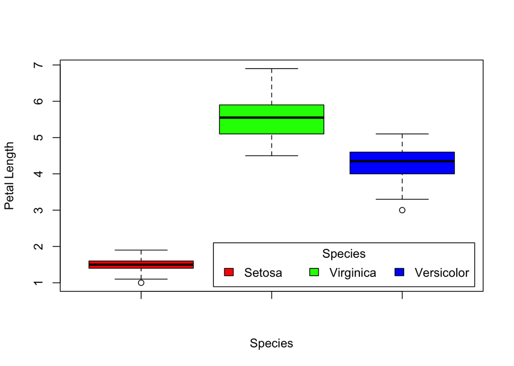

```r
boxplot(pl.setosa, pl.virginica, pl.versicolor, col=c("red", "green", "blue"), xlab="Species", ylab="Petal Length")
legend("bottomright", inset=.02, title="Species", legend=c("Setosa", "Virginica", "Versicolor"), fill=c("red", "green", "blue"), horiz=TRUE)
```